# UNICEF Assignment - Global Health Trends: An Analysis of Infant Mortality, Life Expectancy, and Economic Development

Quarto Report - 2025

Author

Hrishikesh Raghuvir Dharmadhikari - DCU ID - 11928

Published

April 27, 2025

## Introduction

This **UNICEF** report examines global health disparities, focusing on *Infant mortality and the influence of economic development*. The analysis incorporates visualizations of infant death distribution, life expectancy trends, and the relationship between GDP per capita and life expectancy to highlight key challenges and progress in global health.

## Global Infant Mortality Overview

**Global Distribution of Infant Mortality**

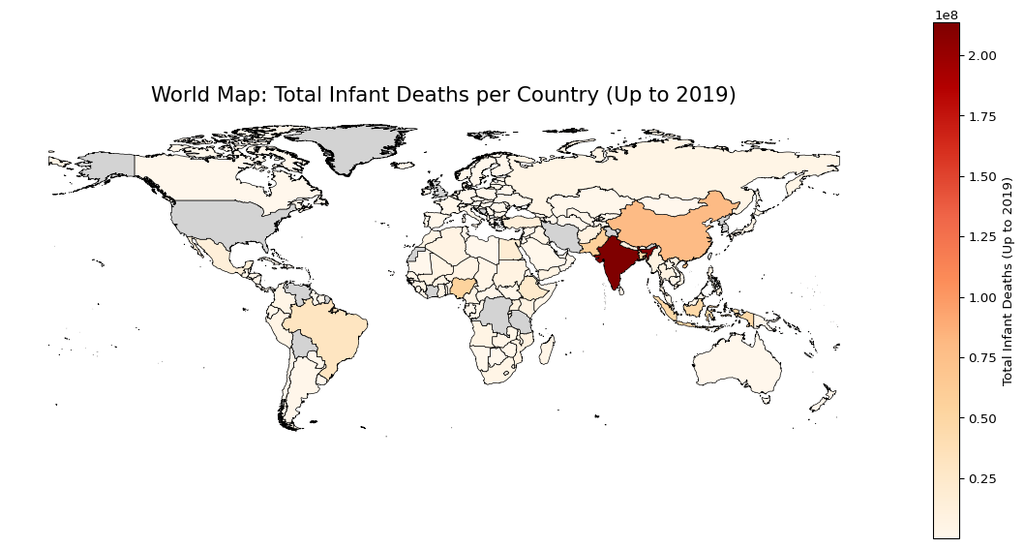

## Life Expectancy Trends

**Life Expectancy Trends: India, Ireland, and China**

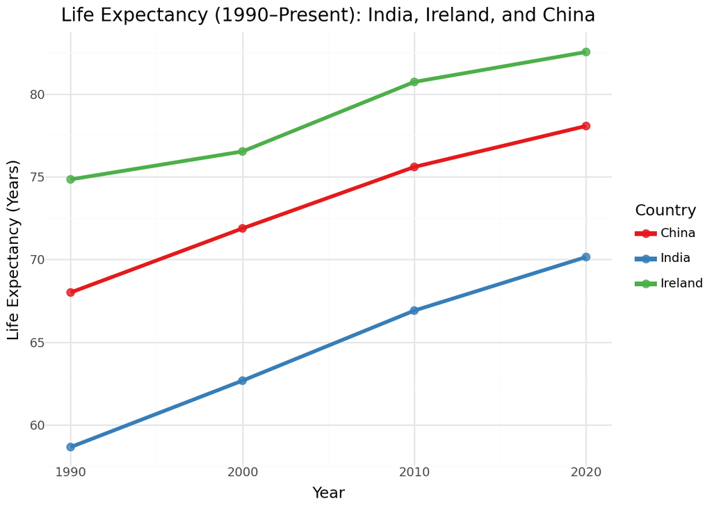

## Economic Context: GDP and Life Expectancy

**Relationship Between GDP per Capita and Life Expectancy**

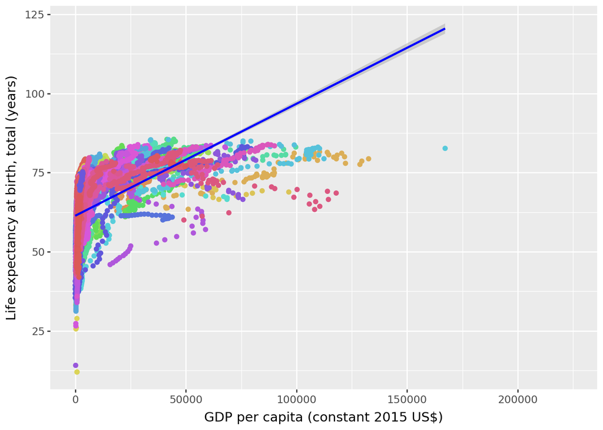

The scatterplot illustrates the relationship between GDP per capita and life expectancy at birth across various countries. The plot reveals a positive correlation, with life expectancy generally increasing as GDP per capita rises. However, the relationship plateaus at higher GDP levels, indicating diminishing returns. Countries with a GDP per capita above $50,000 tend to cluster around a life expectancy of 75-85 years, with little additional gain despite increased wealth, suggesting that factors beyond economic prosperity, such as healthcare quality and access, play a significant role.

## Comparative Analysis

**Synthesis and Discussion**

[figure not shown]

The visualizations collectively highlight persistent regional disparities and the complex interplay between economic development and health outcomes. While the life expectancy trends show significant progress in countries like India and China, these gains must be contextualized with the realities of infant mortality rates and the impact of economic disparities. Targeted interventions and sustained investment in healthcare infrastructure remain crucial for addressing global health challenges effectively.

## Conclusion

In summary, the report underscores the interconnectedness of economic advancement and public health. Addressing disparities requires multifaceted approaches, including sustained investments in healthcare, education, and targeted interventions, to reduce infant mortality and enhance life expectancy globally.